# Task 3: Multiple Regression in R

I will use the RMSE metric for the same reasons as expressed above.

```r
# tuneLenght = 1 (trains with 1 mtry value for RandomForest)
gbmFit1 <- train(Volume~., #y, target
                 data = training, #X, features
                 metric = 'RMSE', #Metric applied
                 method = "gbm", #ML algorithm
                 trControl=gbmfitControl, #Apply CV to the training
                 tuneLength = 10, # Number of levels for each tuning parameters that should be generated
                 verbose = FALSE)
```

[output not shown]

```r
gbmFit1
```

```
Stochastic Gradient Boosting

61 samples
27 predictors

No pre-processing
Resampling: Cross-Validated (10 fold, repeated 1 times)
Summary of sample sizes: 55, 56, 57, 53, 56, 53, ...
Resampling results across tuning parameters:

  interaction.depth  n.trees  RMSE       Rsquared   MAE
   1                  50       860.0736  0.7558457  526.7685
   1                 100       907.4766  0.7523232  567.6180
   1                 150       949.5868  0.6860192  607.5882
   1                 200       982.8493  0.6580634  641.9755
```

[output cut: 101 more lines]

As asked, in this part we are supposed to train a model using Stochastic Gradient Boosting, GBM, on the training set with 10-fold cross-validation and an Automatic Tuning Grid, which is what is coded above.

Train function chooses the model with the largest performance value (or smallest, for mean squared error in regression models), therefore there is no need to select the best iteration of the models.

```r
varImp(gbmFit1)
```

```
gbm variable importance

  only 20 most important variables shown (out of 27)
```

|  | Overall |
| --- | --- |
| x5StarReviews | 100.00000000 |
| ProductNum | 24.80891172 |
| Price | 24.33571885 |
| NegativeServiceReview | 23.73377141 |
| PositiveServiceReview | 20.85808049 |
| x4StarReviews | 20.48923529 |
| x3StarReviews | 13.28397440 |
| ProductHeight | 11.85178959 |
| ProfitMargin | 10.38421111 |
| ShippingWeight | 7.80534054 |

[output cut: 10 more lines]

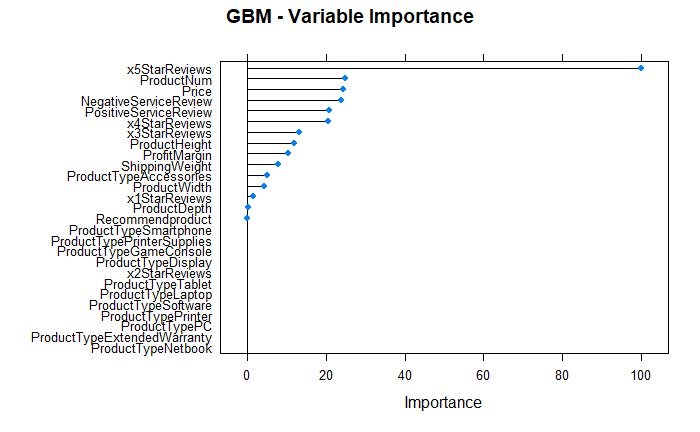

```r
plot(varImp(object=gbmFit1),   main="GBM - Variable Importance")
```

```r
pred_GBM <- predict(gbmFit1, newdata = testing)

Pred_Value_GBM <- predict(gbmFit1, newdata = testing)

postResample(pred_GBM, testing$Volume)
```

```
       RMSE    Rsquared         MAE
360.2649512   0.8971655 324.2107623
```

*Compare the results from the 3 models:*

```r
results <- resamples(list(SVM = svmFit1, GBM=gbmFit1, RF=rfFit1))

summary(results)
```

```
Call:
summary.resamples(object = results)

Models: SVM, GBM, RF
Number of resamples: 10

MAE
           Min.   1st Qu.    Median     Mean  3rd Qu.      Max. NA's
SVM   0.1217658  79.17222 145.08443 216.3648 218.0796  971.7625    0
GBM 193.0578495 297.49133 377.27026 507.2627 423.9626 1458.4460    0
RF   11.3759467  43.61097  82.57266 273.8423 406.6648  988.0062    0

RMSE
           Min.   1st Qu.   Median     Mean  3rd Qu.     Max. NA's
SVM   0.2195709  96.89417 160.5935 361.1476 337.5472 2068.022    0
GBM 232.8033028 333.13639 407.1199 828.6587 549.3621 3341.485    0
RF   13.2836340  91.43742 150.7654 639.1376 938.0178 2576.765    0

Rsquared
         Min.   1st Qu.    Median      Mean   3rd Qu.      Max. NA's
SVM 0.6437794 0.8816451 0.9789983 0.9147411 0.9965709 1.0000000    0
GBM 0.3738967 0.8051909 0.8443659 0.7938977 0.9257263 0.9923769    0
RF  0.9118123 0.9556845 0.9832014 0.9713102 0.9960929 0.9997247    0
```

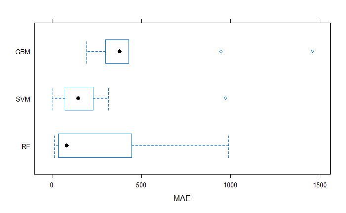

```r
bwplot(results, metric = 'MAE')
```

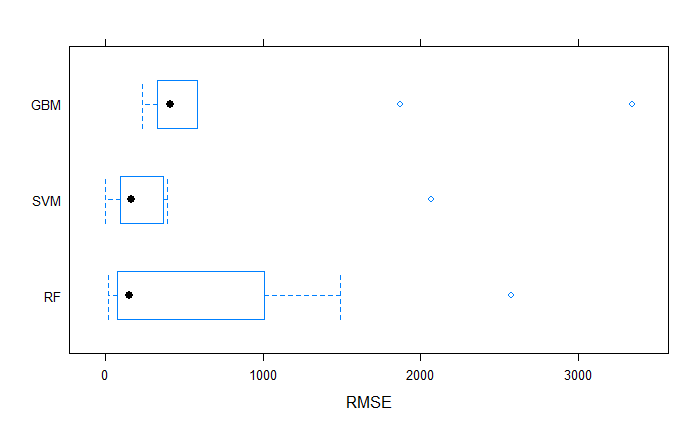

```r
bwplot(results, metric = 'RMSE')
```

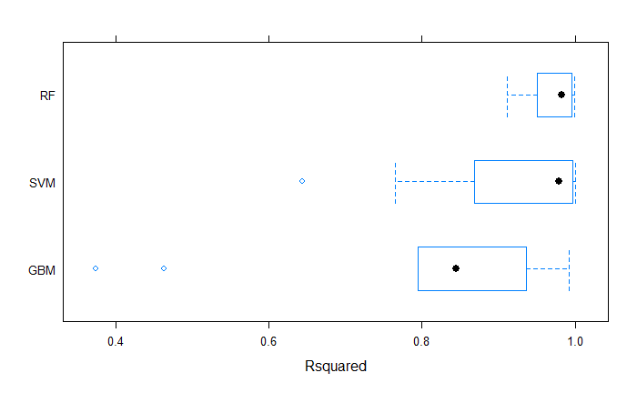

```r
bwplot(results, metric = 'Rsquared')
```

I have plotted the 3 metrics individually due an issue where the x window size is the same for all plots making the Rsquared plot useless.

The pre-process applied on train_df has been equally applied on test_df, therefore no further processing is needed to use this dataset.

```r
prediction<-predict(rfFit1, test_df)
```

```r
postResample(prediction, test_df$Volume)
```

```
     RMSE  Rsquared       MAE
1539.5158        NA  761.8861
```

Not surprisingly the RMSE, Rsquared and MAE are absolutely awful. As mentioned before, the values for the target column of the test dataset seem to have been filled arbitrarily and should not be payed any attention. Therefore, we cannot measure the actual accuracy or any other metric in the test dataset, as there is no true column to compare the forecast against. We must believe that the population from the test dataset behaves similarly to the train dataset and that both datasets have been picked randomly (otherwise the population could have suffer sample selection bias)

```r
summary(prediction)
```

```
    Min.  1st Qu.   Median     Mean  3rd Qu.     Max.
   6.961  143.950  247.566  761.886  482.878 5605.413
```

```r
hist(train_df$Volume)
#hist(test_df$Volume) #Useless
hist(prediction)
```

[output not shown]

```r
output <- test_df

output$predictions <- prediction
write.csv(output, file="C2.T3output.csv", row.names = TRUE)
```

```r
library(babynames)
```

[output not shown]

[output not shown]

[output cut: 70 more lines]

| ProductType | x5star |
| --- | --- |
| Laptop | 516 |
| Netbook | 92 |
| PC | 116 |
| Smartphone | 1808 |

| ProductType | ProductNum | Price | x5StarReviews | x4StarReviews | x3StarReviews | x2StarReviews | x1StarReviews | PositiveServiceReview | NegativeServiceReview | Recommendproduct | BestSellersRank | ShippingWeight | ProductDepth | ProductWidth | ProductHeight | ProfitMargin | Volume |
| --- | --- | --- | --- | --- | --- | --- | --- | --- | --- | --- | --- | --- | --- | --- | --- | --- | --- |
| PC | 101 | 949.00 | 3 | 3 | 2 | 0 | 0 | 2 | 0 | 0.9 | 1967 | 25.80 | 23.94 | 6.62 | 16.89 | 0.15 | 12 |
| PC | 102 | 2249.99 | 2 | 1 | 0 | 0 | 0 | 1 | 0 | 0.9 | 4806 | 50.00 | 35.00 | 31.75 | 19.00 | 0.25 | 8 |
| PC | 103 | 399.00 | 3 | 0 | 0 | 0 | 0 | 1 | 0 | 0.9 | 12076 | 17.40 | 10.50 | 8.30 | 10.20 | 0.08 | 12 |
| Laptop | 104 | 409.99 | 49 | 19 | 8 | 3 | 9 | 7 | 8 | 0.8 | 109 | 5.70 | 15.00 | 9.90 | 1.30 | 0.08 | 196 |
| Laptop | 105 | 1079.99 | 58 | 31 | 11 | 7 | 36 | 7 | 20 | 0.7 | 268 | 7.00 | 12.90 | 0.30 | 8.90 | 0.09 | 232 |
| Accessories | 106 | 114.22 | 83 | 30 | 10 | 9 | 40 | 12 | 5 | 0.3 | 64 | 1.60 | 5.80 | 4.00 | 1.00 | 0.05 | 332 |
| Accessories | 107 | 379.99 | 11 | 3 | 0 | 0 | 1 | 3 | 0 | 0.9 | NA | 7.30 | 6.70 | 10.30 | 11.50 | 0.05 | 44 |
| Accessories | 108 | 65.29 | 33 | 19 | 12 | 5 | 9 | 5 | 3 | 0.7 | 2 | 12.00 | 7.90 | 6.70 | 2.20 | 0.05 | 132 |
| Accessories | 109 | 119.99 | 16 | 9 | 2 | 0 | 2 | 2 | 1 | 0.8 | NA | 1.80 | 10.60 | 9.40 | 4.70 | 0.05 | 64 |
| Accessories | 110 | 16.99 | 10 | 1 | 1 | 0 | 0 | 2 | 0 | 0.9 | 18 | 0.75 | 10.70 | 13.10 | 0.60 | 0.05 | 40 |

[output cut: 70 more lines]

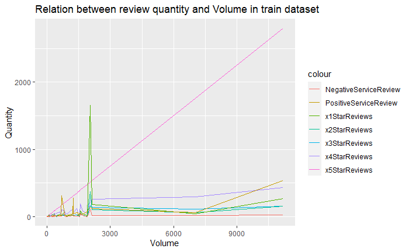

```r
ggplot(plot_train_df, aes(Volume)) +
  geom_line(aes(y = x5StarReviews, colour = "x5StarReviews")) +
  geom_line(aes(y = x4StarReviews, colour = "x4StarReviews")) +
  geom_line(aes(y = x3StarReviews, colour = "x3StarReviews")) +
  geom_line(aes(y = x2StarReviews, colour = "x2StarReviews")) +
  geom_line(aes(y = x1StarReviews, colour = "x1StarReviews")) +
  geom_line(aes(y = PositiveServiceReview, colour = "PositiveServiceReview")) +
  geom_line(aes(y = NegativeServiceReview, colour = "NegativeServiceReview")) +
  labs(title = "Relation between review quantity and Volume in train dataset",  y = "Quantity", x = 'Volume')
```

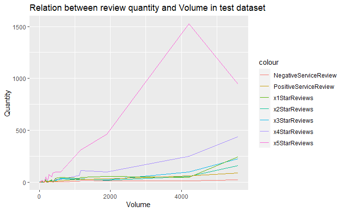

```r
plot_test_df$predictions <- prediction


ggplot(plot_test_df, aes(prediction)) +
  geom_line(aes(y = x5StarReviews, colour = "x5StarReviews")) +
  geom_line(aes(y = x4StarReviews, colour = "x4StarReviews")) +
  geom_line(aes(y = x3StarReviews, colour = "x3StarReviews")) +
  geom_line(aes(y = x2StarReviews, colour = "x2StarReviews")) +
  geom_line(aes(y = x1StarReviews, colour = "x1StarReviews")) +
  geom_line(aes(y = PositiveServiceReview, colour = "PositiveServiceReview")) +
  geom_line(aes(y = NegativeServiceReview, colour = "NegativeServiceReview")) +
  labs(title = "Relation between review quantity and Volume in test dataset",  y = "Quantity", x = 'Volume')
```